# Python for Physics

NUK  
2021 (C) [黃敦紀](https://hackmd.io/@nandemoi/SyqndIE7t) Elton

“*Computer simulation* has become an important and respected research tool, complementing the traditional approaches of *theory* and *experiment*. … [S]imulation can produce revelation, … has the potential to yield the unexpected.” - J. M. Haile in Prolegomena of <Molecular Dynamics Simulation>, *1992*

# 課程安排

[Google Classroom: 代碼 zoaf2s4](https://classroom.google.com/c/NDEyMzkwMjI4MDky?cjc=zoaf2s4)

1. VPython
2. 數值方法工具
3. 專題 (環境安裝問題)

# 執行 VPython 的 2 種方式

1. [Glowscript](https://glowscript.org)
   1. Sign up and sign in
   2. 點框框中間的 “here” 進入你的專題列表
   3. 左上角右邊第二項 “Create New Program” 增加新程式
2. Python IDLE / 命令列 (CLI)。安裝：
   1. [Python](https://www.python.org/downloads/)
   2. `python -m pip install vpython`  
      (MacOS 請打 `pip3 install vpython`)  
      參考[連結](https://www.youtube.com/watch?v=pTlzMwVCEvs): 影片中的 `matplotlib` 換成 `vpython`
- 請注意：網路上許多資源使用舊版 VPython 6 (搭配 Python 2.x, Python 2.x 已停止支援)  
  (開頭會看到 `from visual import *`)

  我們上課使用 VPython 7 (搭配 Python 3.x)

# 程式基本觀念

1. 一行一行循序執行 (和數學演算式的比較)
2. 重複結構 (`while`、`for`) 練習：
   1. 印出 100 以內的奇數、偶數
   2. 印出 100 以內 3 的倍數
   3. 印出 100 以內 2 的指數倍數列
3. 選擇結構 (`if`)、`==`

# 循序執行

1. 變數指定 (*= 等號的意義*, 可參考[連結](http://www.fizika.unios.hr/rf/wp-content/uploads/sites/67/2011/02/CPwP.pdf) 19 頁)、  
   物件`.`屬性 (的)
2. 函式呼叫 (*填表*執行特定功能)：  
   function 功能、數學的函數 (例如：$y=f(x)=x^2$)

# 整數與浮點數

- 電腦中的資料是離散型態的 (非連續)
- 浮點數 (實數) 運算會有誤差
- 乘: `*`  
  除: `/` 浮點數  
  `//` 整數除法 (商)

# 其他

- `#` 開始註解
- Python 是直譯式的: 語法如果有錯要執行到才會報錯

# 空間座標軸

```python
# 匯入 vpyhton 模組 (在 Glowscript 上不需要)
# from vpython import *

# 設定畫布背景顏色為白色
canvas (background = color.white)

#畫出 3D 直角座標沿 x,y,z 方向的單位向量
x = arrow (pos = vector (0,0,0), axis = vector (1,0,0), shaftwidth = 0.02, color=color.green)
y = ... # 請將顏色設定為紅色
z = ... # 請將顏色設定為藍色
```

- VPython Canvas 滑鼠操作：
  1. 中鍵：縮放
  2. 右鍵、Ctrl-左鍵：旋轉場景
  3. Shift-左鍵：移動
- `scene = canvas( background=color.white)`

# 作業繳交說明：

1. Glowscript 程式碼：  
   在程式編輯狀態上面功能最右邊選項：Download  
   下載到本機磁碟後上傳
2. 如何在截圖：[連結](https://www.java.com/zh-TW/download/help/screenshot.html)
3. 如何錄影：  
   Windows ([連結](https://www.playpcesor.com/2017/09/windows-10-record-screen.html))  
   Mac ([連結](https://support.apple.com/zh-tw/HT208721))

# 等速運動 1

任務：用 Python 程式製作一動畫呈現一圓球物體由座標原點出發沿 X 軸做等速運墮

先畫圓球

```python
# 畫球,球的半徑為 size,顏色為黃色,位置在(0,0,0),速度為(1,0,0)
ball = sphere (radius = 0.05, color = color.yellow, pos = vector (0,0,0))
```

# 等速運動 2

任務：用 Python 程式製作一動畫呈現一圓球物體由座標原點出發沿 X 軸做等速運墮

**$x = vt$**

$x_0 = 0$  
$x_1 = x_0 + v\triangle t$

```python
v = vector (1.0,0,0) # 速度向量
dt = 0.2 # 模擬的時間間隔

ball.pos = ball.pos + v*dt # 注意 = 等號的意義
```

# 等速運動 3

任務：用 Python 程式製作一動畫呈現一圓球物體由座標原點出發沿 X 軸做等速運墮

$x_k = x_{k-1} + v \triangle t$  
重複  
但看不清楚，加[延遲](https://www.glowscript.org/docs/VPythonDocs/rate.html)：

```python
ball.pos = ball.pos + v*dt
rate (1/dt) # 延遲 (單位：秒)
ball.pos = ball.pos + v*dt
rate (1/dt)
ball.pos = ball.pos + v*dt
rate (1/dt)
```

# 等速運動 4

`while` loop 迴圈

```python
dt = 0.01 # 模擬的時間間隔
t = 0.0
while t < 2:
    rate (1/dt)
    ball.pos = ball.pos + v*dt
    t = t + dt
```

# 等速運動 1-4

```python
# 匯入 vpyhton 模組 (在 Glowscript 上不需要)
# from vpython import *

# 設定畫布背景顏色為白色
canvas (background = color.white)

#畫出 3D 直角座標沿 x,y,z 方向的單位向量
x = arrow (pos = vector (0,0,0), axis = vector (1,0,0), shaftwidth = 0.02, color=color.green)
y = arrow (pos = vector (0,0,0), axis = vector (0,1,0), shaftwidth = 0.02, color=color.red)
z = arrow (pos = vector (0,0,0), axis = vector (0,0,1), shaftwidth = 0.02, color=color.blue)

ball = sphere (radius = 0.05, color = color.yellow, pos = vector (0,0,0))

v = vector (1.0,0,0)
dt = 0.01 # 模擬的時間間隔
t = 0.0
while t < 2:
    rate (1/dt)
    ball.pos = ball.pos + v*dt
    t = t + dt
```

練習：

1. 試試看不同的速率、運動軸向、模擬時間間隔
   1. 等加速運動：迴圈執行*本體*每次執行時`v`會增加
   2. 平拋運動：y 軸等加速落下，x 軸等速運動
2. 不只一個球、不同速度  
   速度可以設定成 `sphere` 的屬性

   ```python
   ball = sphere (radius = 0.05, color = color.yellow, pos = vector (0,0,0), v = vector (1.0,0,0))
   ```

# 碰撞 1

任務：用 Python 程式製作一動畫呈現一圓球物體在左右兩面牆之間以等速來回運動 (撞到牆就反彈)

畫座標軸後畫兩面牆

```python
left = box (pos = vector (-20,0,0), length = 1, height = 10, width = 1)
rite = ...
```

# 碰撞 2

任務：用 Python 程式製作一動畫呈現一圓球物體在左右兩面牆之間以等速來回運動 (撞到牆就反彈)

畫球從牆出發，設計迴圈撞到牆後反彈

```python
ball = sphere (radius = 0.5, color = color.red, pos = vector (-20,0,0), v = vector (1.0, 0, 0))

dt = 0.1 # 模擬的時間間隔
while True:
    rate (10/dt)
    ball.pos = ball.pos + ball.v*dt
    if ball.pos.x > 20: # 浮點數的比較
        ball.v = vector (-1.0, 0, 0)
```

# 碰撞 n

練習：  
2. 用 Python 程式製作一動畫呈現兩圓球物體各由左右兩面牆以不同速率向彼此等速靠近，碰撞後回彈繼續等速，再碰到牆面後回彈，如此周而復始

- 索引序號從 0 開始

# 參考資料

# Schedule

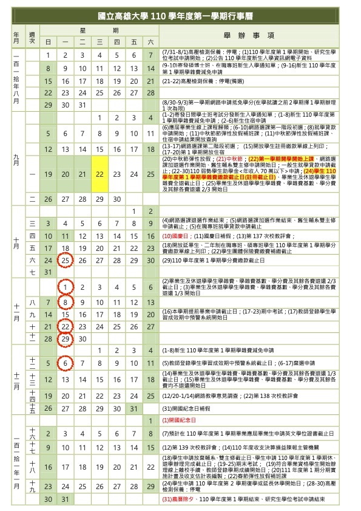

schedule